# 下る

Satoshi Nakagawa

# 1 序

書類は行政区分の上から下へとまわってとっていかなければ なりません。 国の首都ジャカルタの次は、 目的の州、 ヌサ・トゥンガラ・ティムール州の州都であるクパンへ飛びます。 クパンはティモール島にあります。 そこからさらに、 目的の場所の県（カブパテン (Kabupaten)）、 エンデ県の首都[^1]であるエンデの町に行くこととなります。

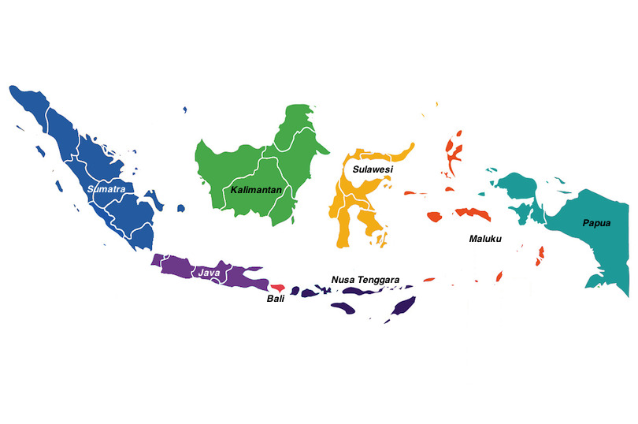

インドネシア

# 2 クパンの町からエンデの町へ

豊かな緑のジャワ島、バリ島を後にします。 いよいよインドネシアの東部にはいります。

私たちは、バリからクパンへ飛ぶ飛行機の中で、 クパンの中国人の牧師さん フーおじさんさんと友だちになりました。 バリからクパンは一時間半ほどのフライトです。 そろそろクパンに着こうというころ、窓際に座っていた フーおじさんさんが僕らを呼んで、窓の外を見ろと言います。 かなりのショックでした──見渡す限り赤茶けた岩だらけなのです。 飛行機の中からでも、 東へ進めば進むほどに乾燥の度合が増していることに、 あなたは気づくでしょう。 緑は少なくなり、乾いた大地があなたを迎えるのです。 それは常夏の楽園のイメージとはかなり異なっているはずです。 東インドネシアはサヴァンナの土地なのです。 ある農学者が東インドネシアを、「インドネシアの中のアフリカ」と 呼んだことがあります──まさにその通りなのです。

クパンは Nusa Tenggara Timur 州の州都のあるところです。

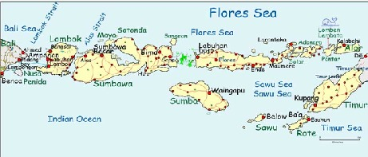

ヌサ・トゥンガラ・ティムール州

ぼくはクパンの町が大好きですが、 旅路をいそいで、 すぐにフローレス島にあるエンデ県のエンデの町へと 歩をすすめましょう。 クパンの町は写真で我慢してください。

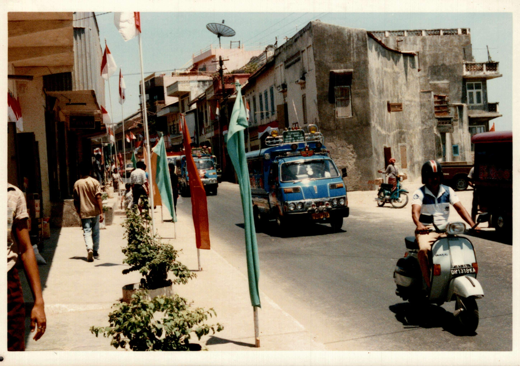

[figure not shown]

## 2.1 町と村

エンデの町についておはなしする前に、 町と村一般についてお話ししたいと思います。

町と田舎の区別は、インドネシア東部ではとても重要な区別です。 じつは、インドネシアの西部、 ジャワやバリでは町も村もたいした違いはないのです。 ジャワやバリの町はいわば大きな村にすぎないと言うことができます。 町では、村と同じようにジャワ語（あるいはバリ語）が 日常使われているのです。 もちろん、村は、いわば、小さな町である、とも言えます。 「インドネシア国家」をどこまでいっても感じることが出来るでしょう。 村の中でも、ルピアを使って簡単に買い物が出来るのですから。

じつは、 インドネシアの外島 （オランダ植民地時代、ジャワ、マドゥーラ島以外はこう呼ばれた）では 概して町と村は大きな違いを持つのです。 ジャワやバリでは、 町にも村にも「インドネシア」が浸透しているけれども、 外島ではインドネシアが意味を持つのは町でだけだ、とも言えます。

外島の町は、逆説的に響くかも知れませんが、 同時に、ジャワ以上にインドネシアが感じられることも事実です。 外島の町はコスモポリタンの雰囲気をもっているのです。 多くのよそ者が町に住みついているのです。 忘れてはならないのは、インドネシアは多民族国家である、という点です。

ジャワでは、どこまでいってもジャワ人が住んでいました。 それは、インドネシアの中では例外的な状況なのです。 フローレス島では、 ちょっと歩けば、言語も習慣も（ことによると顔の造作も）違う人々に 出会えるのです。 外島の町がコスモポリタンだ、 というのはそのような状況の中での意味なのです。

# 3 エンデの町

さて、エンデの町を紹介しましょう。

まず、コトバの問題を整理しておきます。 「エンデ」は、民族および言語の名前であるほかに、 一つの県（カブパテン）の名でもあります。 それはヌサ・トゥンガラ・ティムール（東「東南の島々」）州の中の 一つの県です。

ヌサ・トゥンガラ・ティムール州は、 インドネシアの州の中で、 イスラム教が多数派ではないという点で特別な州でえす。 ただし、エンデ県は、 その州の中でイスラムが重要な地位を占めている特殊な県です。

「エンデ」はまたエンデ県の首都である町の名前です。 エンデの町は、歴史的にイスラムの町でありました。 いまでもエンデの町の旧市街である海岸部はイスラムが多数派を占めています。 エンデの町の人々が起源の地と考えるのは、 エンデの町からすぐ近くにみえる（フローレス海に浮かぶ） エンデ島であす。 エンデ島の住民はほぼ全員がイスラム教徒です。

その他の県（フローレス島の中には全部で５つの県がある）は、 キリスト教が多数派です。 エンデの東のシッカ県や東フローレス県のキリスト教は ポルトガル以来の３００年の歴史を持っています。

さて、この章では、モノレールの視点ではなく、 そこに暮らす人々の視点からエンデを見ていこうと思います。

## 3.1 町の様子

エンデには、 １６世紀、カトリックとイスラムとがほぼ同時に渡来しました。 今は、海岸部のムスリム（イスラム教徒）と 高台のキリスト教徒という図式があります。 １９９８年１月に中国人相手の暴動が起きました。 ２００２年の現在、イスラム教徒とキリスト教徒の間が とてもギクシャクしているようです。 それまでほとんど聞いたことのない、 「少数者」（ミノリタス）という言葉を、 何回か聞くようになりました。 この言葉は、インドネシアにおいてのキリスト教徒の 位置を表す言葉としてもちいられています。 ２００１年からエンデの町に、オジェックというあたらしい 商売が現れました。 オジェックとはバイクの後ろに人を乗せる商売です。 あるキリスト教徒の町の人が言いました── 「オジェックをやっているやつに知った顔はいない。 彼らはすべてアルカイダの手先なのだ」と。

## 3.3 コスモポリタンなエンデの町

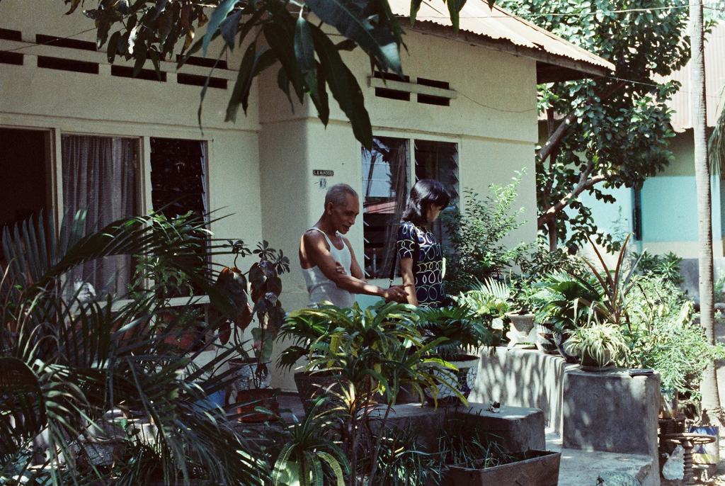

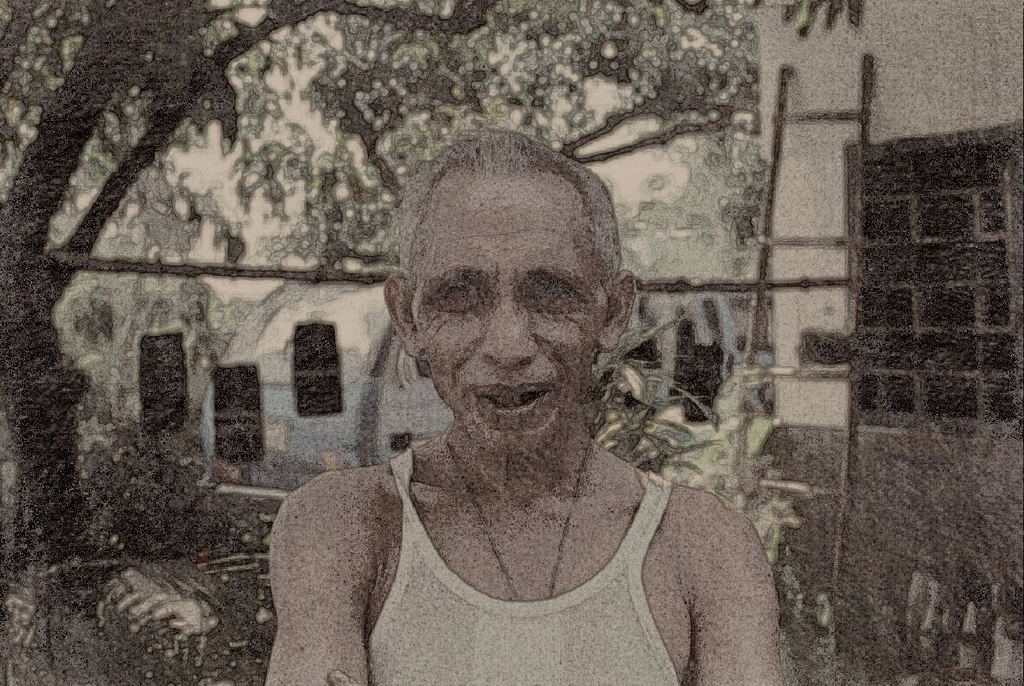

私のエンデの町での最初の知り合いはダ・シルバさんといいます。[^2] 彼は、フローレスの東のララントゥカ出身です。 名前から分かるように、ポルトガル人の子孫です。[^3] ダ・シルバさんの奥さん、ダ・シルバさんの奥さんは、 ティモール島のクパン出身です。 ダ・シルバさんの奥さんは、イギリス人の先祖があります。 オランダの船に乗り込んだイギリスの船員だったという話です。 ダ・シルバさんとダ・シルバさんの奥さんの長女、 リリさんは、ジャワ島のスンダ人と結婚しています。

エンデは、キリスト教の教会によってたてられた 多くの学校があります。 例えば、 シュウラディカラ高校は非常に質の高い教育をすることで知られています。 そういうところから、エンデは「教育の町」としても知られています。 フローレスの西のマンガライ、ンガダから、 エンデの高校にやってくる子どもたちがたくさんいます。 スンバ島出身の人もいます。 皆がインドネシア語をしゃべることになる。

ジャワでは、 町に住んでいる人が村に出かけるのは何でもないことです。 二つの領域を隔てる壁はほとんどないのですから。 しかし、外島では町と村には大きな壁があります。 町の人は、村の人がどんな生活をしているのか、 どんな言葉をしゃべっているのか、 どんなものを食べているのか知らないのです。

エンデは、 港町です。 山が海岸にまで迫っているので、坂の多い町です。 町の上の方にはカトリックの教会があり、 美しい街並みが続きます。 この山の手の町がコスモポリタンのエンデの町なのです。

エンデの町も海岸の方に降りていけば、「村」に近くなります。 坂を下って、海岸の方へ、旧市街の方へ、歩くにつれ、 景観が変わっていきます。 モスクが見えてきます。 そこにはエンデの人々が住んでいる。 夕方、海岸の方を散歩すれば、 多くの人々が道端でしゃがんでいるのに驚くでしょう。 （もっともジャワの生活が永い、あるいは東南アジアの生活 が永い人はそれほど驚かないかもしれないですが。）[^4] そして、彼らが世間ばなしをしているそのことばは、 もはや聞きおぼえのあるインドネシア語ではないことに気付くでしょう。 それがエンデ語なのです。

# 4 幹線道路と海の村

フローレス島を移動するには、 島を縦断している一本の幹線道路を使うしかありません。 ベモとよばれるワゴン車にのり、西に進むことにしましょう。 たまたまパッサール（曜日市場）の日にあたってしまえ ば、ベモは混んでいることを覚悟しなければならない。あなたの足元 でごそごそしているのは、鶏かもしれないし、豚の上に足を乗せなきゃ ならないはめになるかもしれない。とにかく乗せられるだけの荷物 （あるいは人間）をつめこんで、やっとベモは出発する。

それでは、ベモ（乗り合い自動車）に乗って村へ行きましょう。

エンデから西へ行く道は海岸沿いの道である。ベモは１０分くら いおきに村を横切る。海岸の村はたいがいがイスラムの村である。か ならずモスクが一つはある。これらの村には貨幣経済が浸透している。 村の人々は、とった魚を売って生活をしているのだ。ちょうどジャワ の町と村が似ていたように、エンデの町の海岸部と、エンデの海岸の 村は似ている。

さて、私が紹介しようとしているエンデの村はこれらの海岸の村 ではない。山の上の村である。ベモは山の上までは登ってくれない （というか登れない）。適当なところでベモを降りよう。

## 4.1 エンデの村

町から村へと移動すると、風景は一変します。

山の村はたいてい尾根に築かれる。すなわち、かなりのあいだ山 道を登ることになるのだ。あなたは、「インドネシアのアフリカ」を 実感することになるだろう。木が少ないのだ。日差しは強い。時々あ る木陰で、山道から見える海を見ながら、休息しよう。

これからあとは、しばらくエンデの歌の一ジャンル、ウォゾ・ラ ザ、「尾根と道」（あるいは「道行き」という訳が適当かもしれない） に沿って語っていくことにしよう。

しばらくすると、 人の声、犬の声、鶏の声が聞こえます。 ンドゥコ・ヌア、村の近くまで到着したのです。 村に接近する、集落に近づく。 大きな村の中庭を横切りましょう。 犬はあなたに吠えつくかもしれません。 豚がうるさくないているかもしれなません。 さあて、お目当ての家に着きました。 雨をながす溝があります、それをまたいで、家の中庭にはいるのです。 テンダと呼ばれる縁側があります──まずそれによじ登りましょう。 それからもう一つ上の縁側にもあがってかまわいません。 さて、汗も乾いたら、梯子をつたって家の中に入ることになります。 あなたはこの新しい家をよく知るようになったのですから。 緑の家にはなじみなのですから。 扉を開け、かんぬきをゆるめましょう。 入り口を通り、玄関を越えます。 一番奥の壁、ンブッウによっかかりましょう──足は床の上に伸ばして。

かくして、 あなたはエンデの人の家の中に正式の手続きを経て入ったこととなるのです。 ちなみに、すぐ上の段落のウォゾ・ラザ、 「尾根と道」は結婚式の時に 新郎がたどる道筋を歌ったものに手を加えたものです。

エンデの村は１０軒から２０軒くらいの家が、 村の中庭の回りをとりまいてできています。 それほど大きくはありません。 農閑期でもなければ、村に人はほとんどいません。 みんなそれぞれの焼畑で仕事をしているのです。

## 4.2 宗教

山の村はカトリック教徒が大部分を占めている。 といっても、 海岸のイスラム教徒ほどには自分の宗教に熱心なわけではありません。 彼らはとにかくインドネシア政府による 「宗教をもたなければならない」という命令にしたがっているだけなのです。 インドネシア政府に「宗教」と認められているのは、 ５つだけです。 山の村の人たちは、海の村の人たちとは違った宗教を選んだだけなのです。

山の人たちの昔からの宗教は、 死んだ祖先、 野に住む精霊、 至高神などから 構成され、 焼畑の儀礼の中で展開されます。 それについては、次の講義で詳しく述べてます。

それでは、焼畑に行って、 種まきの様子を見てみることにしましょう。

## 4.3 焼畑

畑の真中あたりに何本かの木の枝で、 ２、３メートル四方の儀礼の場所が囲まれています。 そこに呪医がすわり、 目をつぶって種蒔きをおこなっています。 これは野の精霊のための種蒔きなのです。 野の精霊の持ち物である原野を切り開いたそのつぐないのための 畑の中の畑（あるいは畑の中の野原）なのです。 呪医の儀礼が終わった後、 呪医にかわって、 未婚の女が儀礼の場所に座ります。 彼女のまえに容器に入った籾がおかれます。 彼女は、その籾の中から何粒かとりだし、口にいれ、 そして容器の中に再びはきだします。 種蒔きに集まっていた人々は、 その容器の中の籾を、各自、必要な分だけとって、種蒔きするのです。

種蒔きは、 ソンガと呼ばれる共同作業でなされることが多い。 ソンガとは、 動詞としては「（人手を）かり集める」といった意味である。 ソンガには支払いはなされない。 ソンガされて労働に出てきた人が、 ソンガの主に期待するのは、ただ食事だけである。 昼食は畑で食べ、夜はソンガの主の家でとる。

## 4.4 家

一足先に村に帰っておくことにしましょう。 もう夕方です。 アナ・コッカという鳥が、 （子どもがよく言うのですが）自分の名前を歌いはじめます。 人々は、昼間放しておいた鶏や豚を家に呼び戻します。 鶏には「クルルル、クルルル」と、 豚には「キーー、キーー」と、よく通る声で呼びかけるのです。 豚と犬は餌の取り合いをして騒々しい。 餌をもらった鶏はそろそろ手頃な木に止まって、 寝る準備をしています。 場所をお互いにとりあったり、 不器用な鶏はおっこちてしまったり、 ひとわたり木の上の方がさわがしいようです。

ソンガの主の家は、もう夕食の準備ができています。 数人で、豚を屠殺し、解体し、[^5]料理をし[^6]ていたのです。 参加者の中にイスラムの人がいる場合には、 別に山羊や鶏が用意されます。

夜になって、ソンガの人々が集まってきます。 男と女は別々の場所での食事となります。 豚の肉と、米のご飯だ。種蒔きのころ（１２月頃）には、普通の 食事には米はでない。キャサッバがほとんどだ。動物の肉なんてのは、 ソンガじゃなければ、誰かが結婚するか、誰かが死ななければ食べら れない。ヤシ酒（モケ）がふるまわれる。

いろんな話がはずむ。エンデの人は話し上手だ。一人一人が落語 家にだってなれるくらいだ。中年の男が、魚を海岸の村で買って、エ ンデの町で売ったいきさつを話し始める。海岸の村の連中のねばっこ いしゃべり方、エンデの町で出会ったインドネシアの官僚のもったい ぶったインドネシア語の抑揚を、見事に再現してくれる。

どうした成り行きか、日本人が話題の中心になってしまった。お じいさんが尋ねる。「日本でも、インドネシア語をしゃべっているの か。」村を離れれば、共通語のインドネシア語がある。いったん村を 離れれば、どこだってたいした違いはないのだ。ましてや、島を離れ てしまえば、外国であろうが、同じインドネシアの違った島であろう が、たいした違いはない。村にはまだベモに乗ったことのないお年寄 りが何人かいる。エンデの町にさえ、長い人生の中、数えるほどしか 行ったことがないのだ。

そう言えば、村の歴史を簡単に説明してくれた老人がいた。彼に よれば、「一番最初にやって来たのはポルトガル人で、それからオラ ンダ人がやって来た。日本人が少しの間いたが、そのあとすぐインド ネシア人がやってきた。」というのだ。別に「黒い植民者」という、 ステレオタイプ化された政府批判をしているわけではない。実際、ど の植民者も、フローレスのあたりではこれということをしていない。 というのは、これといったものがないからなのだ。彼は、単に事実を 述べているだけなのだ。

一番鶏が鳴いています──そろそろ寝る時間です。

# 5

[^1]: インドネシア語の「イブ・コタ」(ibu kota) という語は、 「首都」という意味のみならず、 それぞれの行政の中心の町をさすことばとなります。 国の首都、州都、県庁所在地、郡長所在地、村役場の所在地、 すべてが「イブ・コタ」なのです。 インドネシア語の感じをだすために、 この講義では「州の首都、県の首都・・・」という言い方を採用します。
[^2]: ジャワの私の友だちの知り合いの知り合いなのです。
[^3]: もっとも、ポルトガル風の姓を持っている人の中には、 ポルトガル人の時代に、功績をあげ、 ポルトガルの姓をもらった先祖をもつ人もいます。 ダ・シルバさんは、じっさいにポルトガル人を先祖にもっているそうです。 じっさい、鼻が高く、なんとなくヨーロッパ風の風貌をしています。
[^4]: この文章は１９８０年代に書いたものを修正しています。 「ジベタリアン」を見慣れた今の日本の人はもうおどろかないでしょう。
[^5]: 以上は男の役割です。
[^6]: 料理が女の役割です。